# Exercise Mode Prediction

localperf

Thursday, October 23, 2014

# Background

Using devices such as Jawbone Up, Nike FuelBand, and Fitbit it is now possible to collect a large amount of data about personal activity relatively inexpensively.

These type of devices are part of the quantified self movement - a group of enthusiasts who take measurements about themselves regularly to improve their health, to find patterns in their behavior, or because they are tech geeks.

One thing that people regularly do is quantify how much of a particular activity they do, but they rarely quantify how well they do it.

Subjects were asked to perform barbell lifts correctly and incorrectly in 5 different ways.

In this project, our goal is to use data from accelerometers on the belt, forearm, arm, and dumbell of 6 participants to predict an exercise mode : either a correct exercise, or a wrong exercise execution in one of 4 ways. The 5 modes are coded in the data as A,B,C.D, and E.

More information is available from the website here: http://groupware.les.inf.puc-rio.br/har (see the section on the Weight Lifting Exercise Dataset).

# Data

The training data for this project are available here:

https://d396qusza40orc.cloudfront.net/predmachlearn/pml-training.csv

The test data are available here:

https://d396qusza40orc.cloudfront.net/predmachlearn/pml-testing.csv

The data for this project come from this source: http://groupware.les.inf.puc-rio.br/har.

# Variable Selection

The training data have 19,622 rows and 160 columns. An examination of the first rows shows that the first column is a row sequence number, and the next six columns are user_name, three timestamp values, and two “window” variables. Since those seven fields are not physiologic, they were deleted.

Further investidation showed that 100 columns were mostly “missing”: each had more than 19,000 (more than 95%) missing values. Those columns were dropped, and the remaining data were saved as train2.

```r
library (caret)
library (dplyr)
```

```r
library (ggplot2)
library (randomForest)
get.data = function () {
   #--read data and discard non-physiologic variables
   #--19622 rows, 160 columns

   train = read.csv ("pml-training.csv", na.strings = c("NA", "#DIV/0!", ""))
   train = tbl_df(train)
   colnames(train)[1] = "seq"
   train
   dim(train)
   summary(train)

   z = grep ("timestamp", colnames(train))
   colnames(train)[z]
   train = train[,-z]

   z = grep("user_name", colnames(train))
   train = train[,-z]

   train$seq         = NULL
   train$new_window  = NULL
   train$num_window  = NULL

   dim(train)
   head(colnames(train))
   train
}

drop.na.columns = function (df) {
   #--drop columns if they have any NAs
   counts = data.frame(var = colnames(df))
   for (var in colnames(df)) {
      counts$na[counts$var == var] = sum (is.na(df[,var]))
   }
   na.counts = colSums(is.na(df)) == 0
   df2 = df[, na.counts ]
   df2
}

train = get.data()

#explore (train) #--summarize columns by NA count

train2 = drop.na.columns(train)
dim(train2)
```

```
## [1] 19622    53
```

At this point, train2 has 52 predictors, and one one outcome (“classe”).

# Random Forest

I decided to use the randomForest procedure in the R randomForest package to build a classification prediction model.

```r
set.seed (1188)
ntree = 50
fit.rf = randomForest (classe ~ ., data = train2, importance = T, ntree = ntree)
predicted = predict (fit.rf, train, type = "class")

mc = table (train2$classe, predicted)
mc
```

```
##    predicted
##        A    B    C    D    E
##   A 5580    0    0    0    0
##   B    0 3797    0    0    0
##   C    0    0 3422    0    0
##   D    0    0    0 3216    0
##   E    0    0    0    0 3607
```

The accuracy of the classifier is 100% - an unexpected,but welcome, outcome. The ntree parameter in the call to randomForest specifies a number of trees to be built, and deafults to 500. I reduced the value until the accuracy was less than 100%, which occurred near 15 trees. The plot below shows that mis-classification rates fall off very rapidly with ibncreasing tree counts.

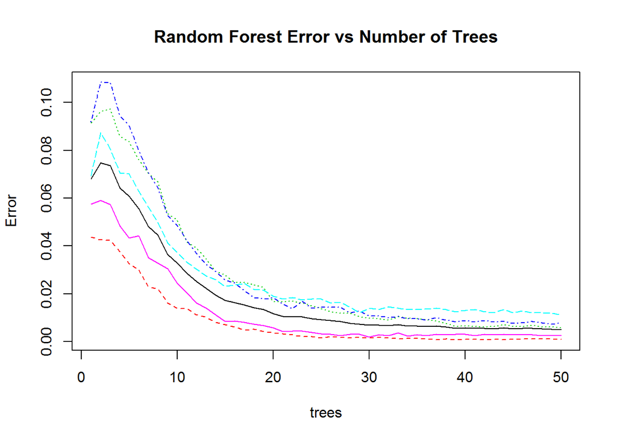

```r
plot (fit.rf, main = "Random Forest Error vs Number of Trees")
```

# Variable Importance

```r
imp.rf = as.data.frame(randomForest::importance(fit.rf, type = 2))
imp.rf$var = row.names(imp.rf)
imp.rf = imp.rf[order(-imp.rf$MeanDecreaseGini),]
row.names(imp.rf) = NULL
head (imp.rf)
```

```
##   MeanDecreaseGini               var
## 1           1083.9         roll_belt
## 2           1005.5          yaw_belt
## 3            789.5 magnet_dumbbell_z
## 4            738.2     pitch_forearm
## 5            738.0        pitch_belt
## 6            649.0 magnet_dumbbell_y
```

```r
tail (imp.rf)
```

```
##    MeanDecreaseGini              var
## 47            99.11     gyros_belt_y
## 48            96.18     gyros_belt_x
## 49            84.61  gyros_forearm_z
## 50            82.58 gyros_dumbbell_z
## 51            76.30  gyros_forearm_x
## 52            50.71      gyros_arm_z
```

# Cross-validation

I decided to implement 10-fold cross validation.

To do this, I divided the training data into 10 nearly-equally-sized folds, with a random assignment of rows to folds. For each fold, I created training and test subsets composed of all the training data but the fold, and the fold, respectively. I then used the same call to randomForest as used to build the model above, 10 times, once with each of the new training subsets. I then scored that model on the held out test data. The routine below returns a vector of the ten computed accuracies.

```r
k.fold.rf.cross = function (df, ntree, K = 10) {
   #--build K models, holding out 1/K of the data each time
   #--and then scoring against the held out data
   n  = dim (df)[1]
   u  = runif (n)
   df = df[order(u),]
   length(unique(u))   #--shuffle the rows

   row = 1:dim(df)[1]
   folds = row %% K
   head (folds, 20)
   accuracy = NULL
   table (folds)
   for (fold in unique(folds)) {
      local = df[-which(folds == fold),]
      test  = df[ which(folds == fold),]
      local.fit = randomForest (classe ~ ., data = local, ntree=ntree, type = "class")
      predicted = predict (local.fit, test, type = "class")
      mc = table (test$classe, predicted)
      accuracy = c(accuracy, sum(diag(mc)) / sum (mc))
   }
   accuracy
}

set.seed (271828)

accuracy = k.fold.rf.cross (train2, ntree=ntree, K = 10)
summary(accuracy)
```

```
##    Min. 1st Qu.  Median    Mean 3rd Qu.    Max.
##   0.993   0.996   0.996   0.996   0.996   0.997
```

As shown above, the accuracy remains very high - above 99% for all 10 folds.

# Expectation for Out of Sample Error

The cross validation results suggest the out of sample error should be quite small, on the order of 1% or less.